# 30.11.2020

# **Exercise 6: Analysis of longitudinal data**

#### **Description of analysed data sets**

For this weeks exercise, I’m using two data sets. First I’ll start with a data set called ratsl. That data set contains information from a nutrition study conducted in three groups of rats. The groups were put on different diets, and each rats’ body weight (grams) was recorded repeatedly over a 9-week period.

The second data set contains information of some medical treatments. the data set includes BPRS rates (brief word for the brief psychiatric rating scale) of two different treatment groups of 20 man. These patients BPRS levels were followed every week for 8 weeks.

Read more about the data sets from [this books](https://mooc.helsinki.fi/pluginfile.php/143981/course/section/5444/MABS4IODS.pdf) chapters 8 and 9.

```r
#Opening packages
library(psych)
library(tidyr)
library(ggplot2)
library(tidyverse)
library(knitr)

#Reading the data
ratsl <- read.table("data/RATSL.txt")
bprsl <- read.table("data/BPRSL.txt")

#Checking the data
str(ratsl)
str(bprsl)

#Looks that I have to factor some of the variables again
bprsl$treatment <- factor(bprsl$treatment)
bprsl$subject <- factor(bprsl$subject)

ratsl$ID <- factor(ratsl$ID)
ratsl$Group <- factor(ratsl$Group)

str(ratsl)
str(bprsl)
#Now everything is okey for the analysis
```

First, I’ll start with analyzing ratsl by graphical displays and summary measure approach.

```r
summary(ratsl)
```

```
##        ID      Group      WDs                 rats            time
##  1      : 11   1:88   Length:176         Min.   :225.0   Min.   : 1.00
##  2      : 11   2:44   Class :character   1st Qu.:267.0   1st Qu.:15.00
##  3      : 11   3:44   Mode  :character   Median :344.5   Median :36.00
##  4      : 11                             Mean   :384.5   Mean   :33.55
##  5      : 11                             3rd Qu.:511.2   3rd Qu.:50.00
##  6      : 11                             Max.   :628.0   Max.   :64.00
##  (Other):110
```

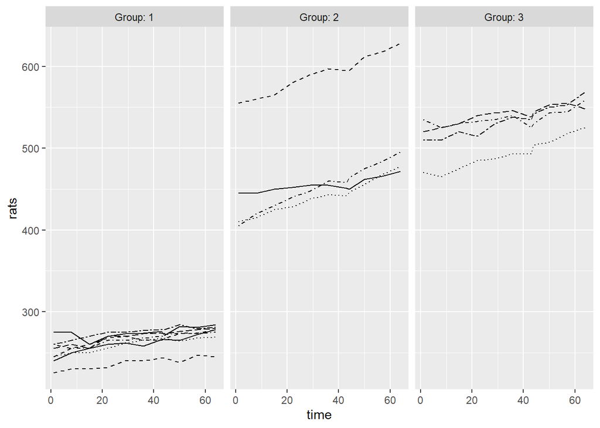

```r
# Draw the plot
ggplot(ratsl, aes(x = time, y = rats, linetype = ID)) +
  geom_line() +
  scale_linetype_manual(values = rep(1:10, times=4)) +
  facet_grid(. ~ Group, labeller = label_both) +
  theme(legend.position = "none") +
  scale_y_continuous(limits = c(min(ratsl$rats), max(ratsl$rats)))
```

From the graphic above we can see lines that show rats’ individual growth in time in each three groups. In group 1, the rats seems to be generally smaller than in other groups. In group 2, there seem to be one giant rat but the other group 2 members are smaller that rats in group 3. Generally it looks like the rats’ weight increase in all three groups, but the growth is more settle in group 1.

Next I’ll standardize the weight of the rats to see how it effects to the results.

```r
# Standardise the variable rats
ratsl2 <- ratsl %>%
  group_by(time) %>%
  mutate(std_weight = (rats - mean(rats))/sd(rats) ) %>%
  ungroup()

# Glimpse the data
glimpse(ratsl2)
```

```
## Rows: 176
## Columns: 6
## $ ID         <fct> 1, 2, 3, 4, 5, 6, 7, 8, 9, 10, 11, 12, 13, 14, 15, 16, 1...
## $ Group      <fct> 1, 1, 1, 1, 1, 1, 1, 1, 2, 2, 2, 2, 3, 3, 3, 3, 1, 1, 1,...
## $ WDs        <chr> "WD1", "WD1", "WD1", "WD1", "WD1", "WD1", "WD1", "WD1", ...
## $ rats       <int> 240, 225, 245, 260, 255, 260, 275, 245, 410, 405, 445, 5...
## $ time       <int> 1, 1, 1, 1, 1, 1, 1, 1, 1, 1, 1, 1, 1, 1, 1, 1, 8, 8, 8,...
## $ std_weight <dbl> -1.0011429, -1.1203857, -0.9613953, -0.8421525, -0.88190...
```

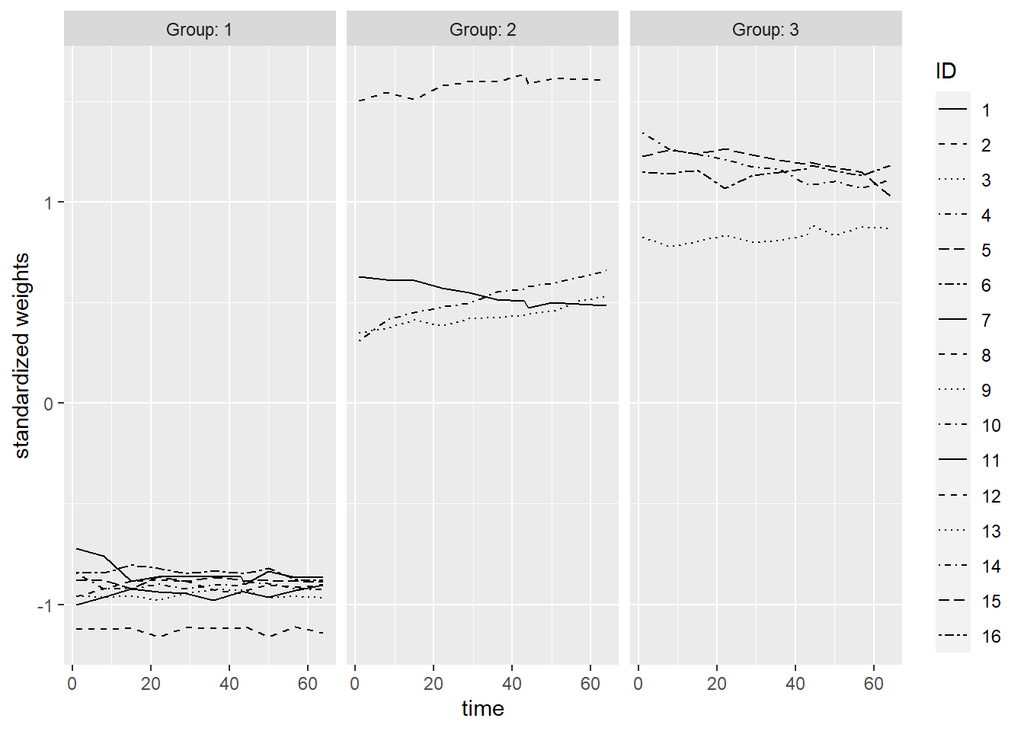

```r
# Plot again with the standardized weights
ggplot(ratsl2, aes(x = time, y = std_weight, linetype = ID)) +
  geom_line() +
  scale_linetype_manual(values = rep(1:10, times=4)) +
  facet_grid(. ~ Group, labeller = label_both) +
  scale_y_continuous(name = "standardized weights")
```

Now when we look above, we can see that now the growth in each group is more settled.

Next, I’ll draw some summary graphs that describe better the change over time in group levels. See bellow a plot figure with averaged over the group-specific means by time point.

```r
# Number of weeks, baseline (week 0) included
n <- ratsl2$time %>% unique() %>% length()

# Summary data with mean and standard error of weight by group and time point
ratss <- ratsl2 %>%
  group_by(Group, time) %>%
  summarise( mean = mean(rats), se = sd(rats)/sqrt(n) ) %>%
  ungroup()
# Glimpse the data
glimpse(ratss)
```

```
## Rows: 33
## Columns: 4
## $ Group <fct> 1, 1, 1, 1, 1, 1, 1, 1, 1, 1, 1, 2, 2, 2, 2, 2, 2, 2, 2, 2, 2...
## $ time  <int> 1, 8, 15, 22, 29, 36, 43, 44, 50, 57, 64, 1, 8, 15, 22, 29, 3...
## $ mean  <dbl> 250.625, 255.000, 254.375, 261.875, 264.625, 265.000, 267.375...
## $ se    <dbl> 4.589478, 3.947710, 3.460116, 4.100800, 3.333956, 3.552939, 3...
```

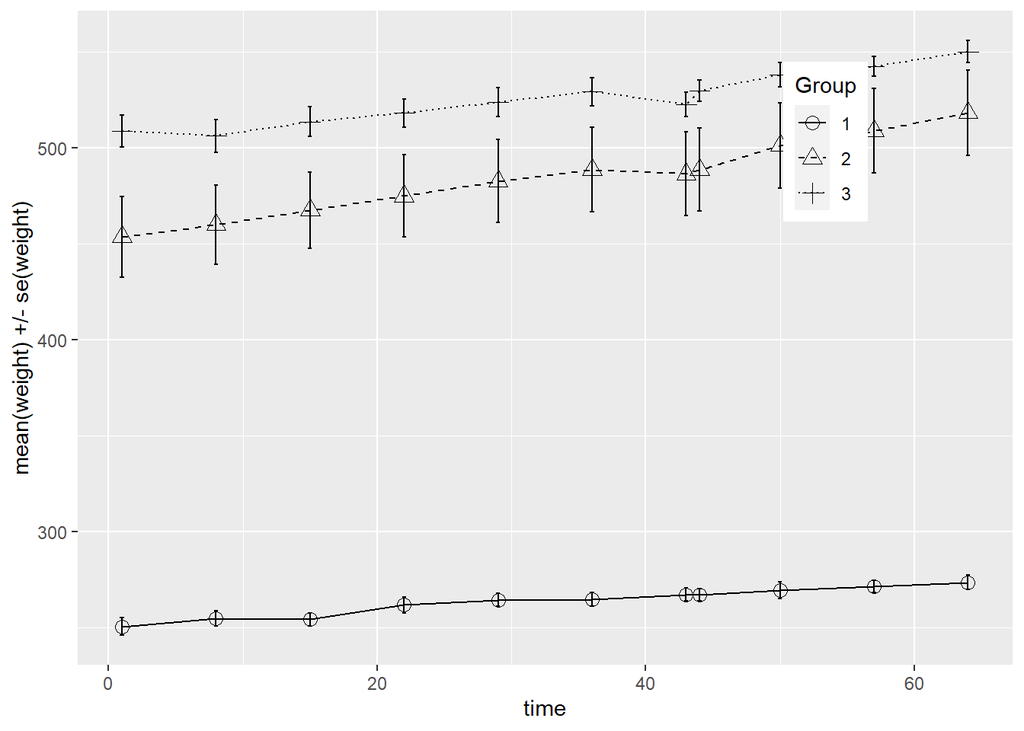

```r
# Plot the mean profiles
ggplot(ratss, aes(x = time, y = mean, linetype = Group, shape = Group)) +
  geom_line() +
  scale_linetype_manual(values = c(1,2,3)) +
  geom_point(size=3) +
  scale_shape_manual(values = c(1,2,3)) +
  geom_errorbar(aes(ymin = mean - se, ymax = mean + se, linetype="1"), width=0.3) +
  theme(legend.position = c(0.8,0.8)) +
  scale_y_continuous(name = "mean(weight) +/- se(weight)")
```

From the plot graph above, we can see that group 1 rats are much smaller than the other rats and their weights don’t increase that much over time. The standard error of group 2 is pretty wide. This must have something to do with the fact that there is one giant rat in group 2. That rat is an outlier. Let’s see next weather there is other outliers in the groups.

```r
# Create a summary data by group and ID with mean as the summary variable (ignoring baseline week 0).
ratsl8S <- ratsl %>%
  filter(time > 0) %>%
  group_by(Group, ID) %>%
  summarise( mean=mean(rats) ) %>%
  ungroup()
# Glimpse the data
glimpse(ratsl8S)
```

```
## Rows: 16
## Columns: 3
## $ Group <fct> 1, 1, 1, 1, 1, 1, 1, 1, 2, 2, 2, 2, 3, 3, 3, 3
## $ ID    <fct> 1, 2, 3, 4, 5, 6, 7, 8, 9, 10, 11, 12, 13, 14, 15, 16
## $ mean  <dbl> 261.0909, 237.6364, 260.1818, 266.5455, 269.4545, 274.7273, 2...
```

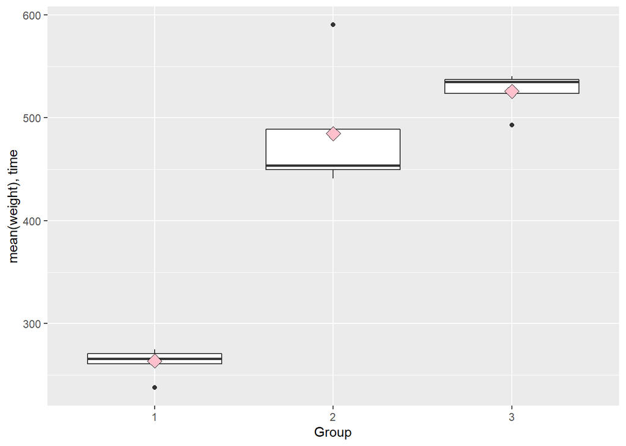

```r
# Draw a boxplot of the mean versus Group
ggplot(ratsl8S, aes(x = Group, y = mean)) +
  geom_boxplot() +
  stat_summary(fun = "mean", geom = "point", shape=23, size=4, fill = "pink") +
  scale_y_continuous(name = "mean(weight), time")
```

```r
#Filltering out the ouliers

ratsl8S1 <- ratsl8S %>%
  filter(ID !=2 & ID !=12 & ID !=13)
```

There seems to be one outlier in each group but the outlier in group 2 is the most obvious one. The outliers in groups 1 and 3, are the rats with the lowest means. I will continue the analyses by excluding all the three outliers.

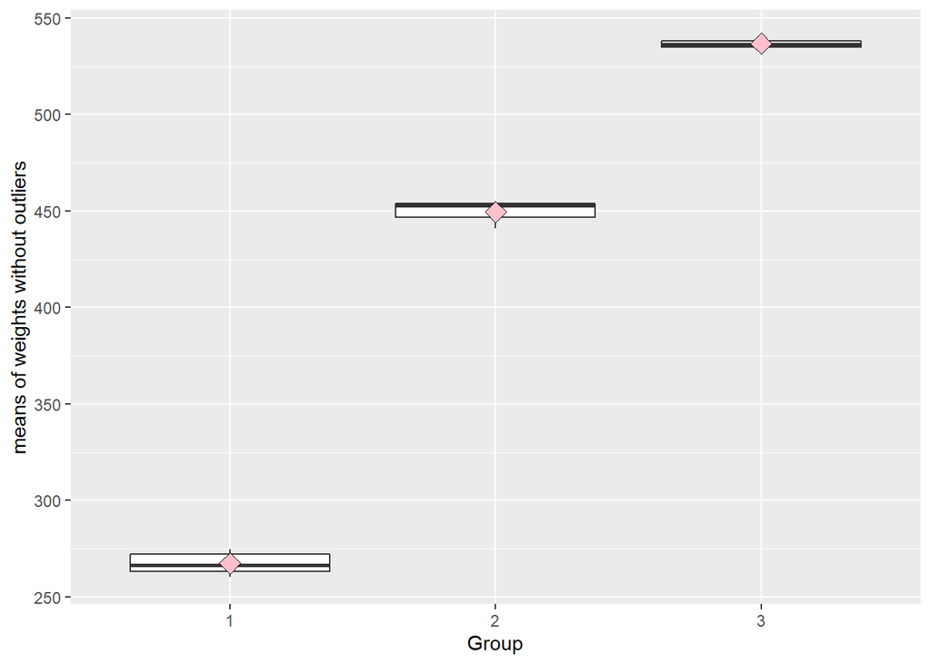

```r
ggplot(ratsl8S1, aes(x = Group, y = mean)) +
  geom_boxplot() +
  stat_summary(fun  = "mean", geom = "point", shape=23, size=4, fill = "pink") +
  scale_y_continuous(name = "means of weights without outliers")
```

Since I have more than two groups, I’ll use ANOVA to explore the statistically significant differences between the groups.